# Assignment 12

Our goal is to see if we can use an autoencoder to remove noise.

# Task 1: Get the data

Use the ae_emnist_simple.ipynb to get the data. Include the code from the code block under "Subselect just the digits"

```python
import tensorflow as tf
from tensorflow import keras
print(tf.__version__)
print(keras.__version__)
import numpy as np
import pandas as pd
%matplotlib inline
import matplotlib.pyplot as plt


emnist_arrays_npz = np.load("emnist_train_test.npz")
emnist_test_images = emnist_arrays_npz["arr_0"]
emnist_test_labels = emnist_arrays_npz["arr_1"]
print("Shape of array 1",emnist_test_images.shape)
print("Shape of array 2",emnist_test_labels.shape)
emnist_train_images = emnist_arrays_npz["arr_2"]
emnist_train_labels = emnist_arrays_npz["arr_3"]
print("Shape of array 3",emnist_train_images.shape)
print("Shape of array 4",emnist_train_labels.shape)


ex_train = emnist_train_images.astype('float32') / 255.
ex_test = emnist_test_images.astype('float32') / 255.

df_train = pd.DataFrame(ex_train.reshape(len(ex_train),784))
df_train['label'] = emnist_train_labels

df_test = pd.DataFrame(ex_test.reshape(len(ex_test),784))
df_test['label'] = emnist_test_labels


print("Done!")
```

```
2.6.0
2.6.0
Shape of array 1 (19505, 28, 28, 1)
Shape of array 2 (19505,)
Shape of array 3 (119098, 28, 28, 1)
Shape of array 4 (119098,)
Done!
```

```python
# Get just the digits
df_digits_train = df_train[df_train['label']<=9]
x_train = df_digits_train.iloc[:,:784].values
x_train = x_train.reshape( (x_train.shape[0], 28,28,1))
y_train = df_digits_train['label'].values
print("Shape x_train",x_train.shape)
print("Shape y_train",y_train.shape)

df_digits_test = df_test[df_test['label']<=9]
x_test = df_digits_test.iloc[:,:784].values
x_test = x_test.reshape( (x_test.shape[0], 28,28,1))
y_test = df_digits_test['label'].values
```

```
Shape x_train (25340, 28, 28, 1)
Shape y_train (25340,)
```

# Task 2: Add code for adding noise to images

Look at add_noise.ipynb for this.

1. Add noise to both the x_train and x_test data.
2. Display 10 digits with and without noise from the training data.

```python
noise_factor = 0.5
x_train_noisy = x_train + noise_factor * np.random.normal(loc=0.0, scale=1.0, size=x_train.shape)
x_test_noisy = x_test + noise_factor * np.random.normal(loc=0.0, scale=1.0, size=x_test.shape)
```

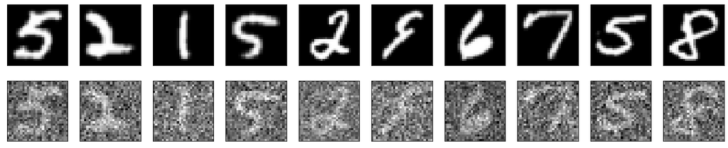

```python
n = 10  # how many digits we will display
plt.figure(figsize=(20, 4))
for i in range(n):
    # display original
    ax = plt.subplot(2, n, i + 1)
    plt.imshow(x_train[i].reshape(28, 28))
    plt.gray()
    ax.get_xaxis().set_visible(False)
    ax.get_yaxis().set_visible(False)

    # display reconstruction
    ax = plt.subplot(2, n, i + 1 + n)
    plt.imshow(x_train_noisy[i].reshape(28, 28))
    plt.gray()
    ax.get_xaxis().set_visible(False)
    ax.get_yaxis().set_visible(False)
plt.show()
```

## Task 3: Get Network from ae_mnist_simple

Get the autoencoder and fit it.

Use:

- input_data = x_train
- target_data = x_train

```python
#print(history.history)
network = keras.models.load_model('models/ae_fcn_128.h5')
input_data = x_train
target_data = x_train
print(input_data.shape)
```

```
(25340, 28, 28, 1)
```

## Fitting

Note that in fitting we use **x_train** for both the input features and the targets.

```python
history = network.fit(input_data, target_data,
                epochs=5,
                batch_size=128,
                shuffle=True,
                validation_data=(x_test, x_test))
```

## Task 4: Apply model to non-noisy images

We apply the model and plot the original vs model output.

Do the following:

- run network.predict on the x_test images:

  ```
      decoded_imgs = network.predict(x_test)
  ```

- Plot 10 x_test images and their decoded counterparts decoded_imgs (see Performance, Part II in ae_emnist_simple).

```python
decoded_imgs = network.predict(x_test)
```

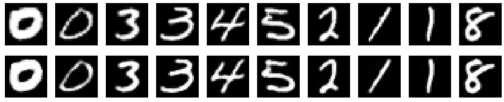

```python
%matplotlib inline
import matplotlib.pyplot as plt

n = 10  # how many digits we will display
plt.figure(figsize=(20, 4))
for i in range(n):
    # display original
    ax = plt.subplot(2, n, i + 1)
    plt.imshow(x_test[i].reshape(28, 28))
    plt.gray()
    ax.get_xaxis().set_visible(False)
    ax.get_yaxis().set_visible(False)

    # display reconstruction
    ax = plt.subplot(2, n, i + 1 + n)
    plt.imshow(decoded_imgs[i].reshape(28, 28))
    plt.gray()
    ax.get_xaxis().set_visible(False)
    ax.get_yaxis().set_visible(False)
plt.show()
```

## Task 5: Apply model to noisy images

We apply the model to the **noisy** images and plot the original vs model output.

- run network.predict on the x_test_noisy images:

  ```
      decoded_imgs_noisy = network.predict(x_test_noisy)
  ```

- Plot 10 x_test_noisy images and their decoded counterparts decoded_imgs_noisy (see Performance, Part II in ae_emnist_simple).

```python
decoded_imgs_noisy = network.predict(x_test_noisy)
```

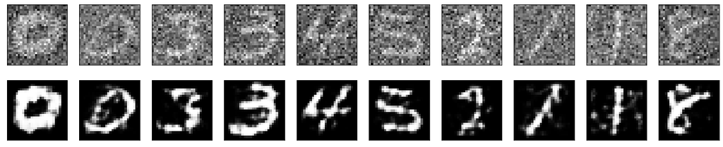

```python
n = 10  # how many digits we will display
plt.figure(figsize=(20, 4))
for i in range(n):
    # display original
    ax = plt.subplot(2, n, i + 1)
    plt.imshow(x_test_noisy[i].reshape(28, 28))
    plt.gray()
    ax.get_xaxis().set_visible(False)
    ax.get_yaxis().set_visible(False)

    # display reconstruction
    ax = plt.subplot(2, n, i + 1 + n)
    plt.imshow(decoded_imgs_noisy[i].reshape(28, 28))
    plt.gray()
    ax.get_xaxis().set_visible(False)
    ax.get_yaxis().set_visible(False)
plt.show()
```

## Task 6: Now compare original to decoded noisy.

- Plot 10 original x_test images (the ones that generated the x_test_noisy images) and the corresponding decoded_imgs_noisy.

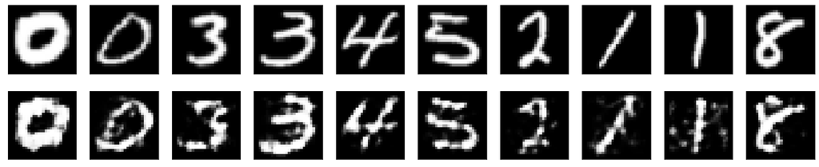

```python
n = 10  # how many digits we will display
plt.figure(figsize=(20, 4))
for i in range(n):
    # display original
    ax = plt.subplot(2, n, i + 1)
    plt.imshow(x_test[i].reshape(28, 28))
    plt.gray()
    ax.get_xaxis().set_visible(False)
    ax.get_yaxis().set_visible(False)

    # display reconstruction
    ax = plt.subplot(2, n, i + 1 + n)
    plt.imshow(decoded_imgs_noisy[i].reshape(28, 28))
    plt.gray()
    ax.get_xaxis().set_visible(False)
    ax.get_yaxis().set_visible(False)
plt.show()
```

## Task 7: Now use the noisy images as the input when fitting

Use:

- input_data = x_train_noisy
- target_data = x_train

and train the neywork.

```python
#print(history.history)
network = keras.models.load_model('models/ae_fcn_128.h5')
input_data = x_train_noisy
target_data = x_train
print(input_data.shape)
```

```
(25340, 28, 28, 1)
```

```python
history = network.fit(input_data, target_data,
                epochs=5,
                batch_size=128,
                shuffle=True,
                validation_data=(x_test, x_test))
```

## Task 8: Compare the input noisy images to their decoded versions

Do the following:

- run network.predict on the x_test_noisy images:

  ```
      decoded_imgs_noisy = network.predict(x_test_noisy)
  ```

- Plot 10 x_test_noisy images and their decoded counterparts decoded_imgs (see Performance, Part II in ae_emnist_simple).

```python
decoded_imgs_noisy = network.predict(x_test_noisy)
```

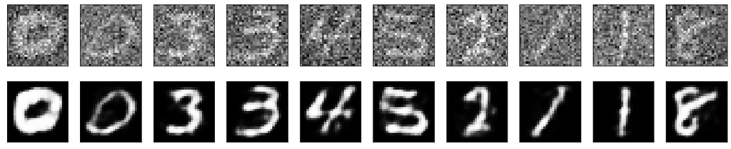

```python
n = 10  # how many digits we will display
plt.figure(figsize=(20, 4))
for i in range(n):
    # display original
    ax = plt.subplot(2, n, i + 1)
    plt.imshow(x_test_noisy[i].reshape(28, 28))
    plt.gray()
    ax.get_xaxis().set_visible(False)
    ax.get_yaxis().set_visible(False)

    # display reconstruction
    ax = plt.subplot(2, n, i + 1 + n)
    plt.imshow(decoded_imgs_noisy[i].reshape(28, 28))
    plt.gray()
    ax.get_xaxis().set_visible(False)
    ax.get_yaxis().set_visible(False)
plt.show()
```

## Task 9: Compare the original non-noisy images to their decoded versions

- Here, plot 10 original x_test images (the ones that generated the x_test_noisy images) and the decoded_imgs_noisy.

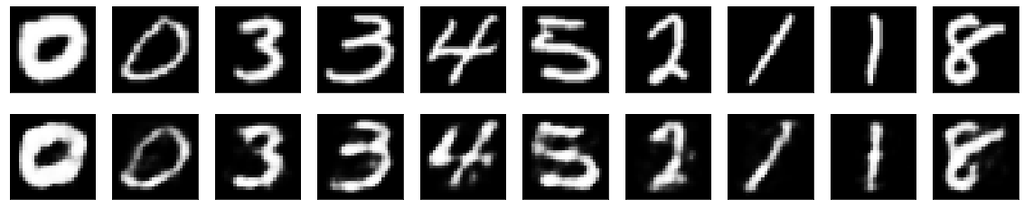

```python
n = 10  # how many digits we will display
plt.figure(figsize=(20, 4))
for i in range(n):
    # display original
    ax = plt.subplot(2, n, i + 1)
    plt.imshow(x_test[i].reshape(28, 28))
    plt.gray()
    ax.get_xaxis().set_visible(False)
    ax.get_yaxis().set_visible(False)

    # display reconstruction
    ax = plt.subplot(2, n, i + 1 + n)
    plt.imshow(decoded_imgs_noisy[i].reshape(28, 28))
    plt.gray()
    ax.get_xaxis().set_visible(False)
    ax.get_yaxis().set_visible(False)
plt.show()
```

Use:

Do the following:

- run network.predict on the x_test_noisy images:

  ```
      decoded_imgs_noisy = network.predict(x_test_noisy)
  ```

- Plot 10 x_test images and their decoded counterparts decoded_imgs (see Performance, Part II in ae_emnist_simple).
- run network.predict on the x_test images:

  ```
      decoded_imgs = network.predict(x_test)
  ```

- Plot 10 x_test images and their decoded counterparts decoded_imgs (see Performance, Part II in ae_emnist_simple).

```python
#print(history.history)
network = keras.models.load_model('models/ae_fcn_128.h5')
input_data = x_train_noisy
target_data = x_train_noisy
print(input_data.shape)
```

```
(25340, 28, 28, 1)
```

```python
decoded_imgs_noisy = network.predict(x_test_noisy)
```

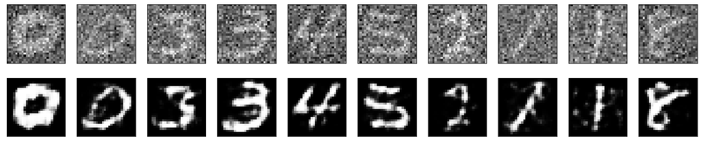

```python
n = 10  # how many digits we will display
plt.figure(figsize=(20, 4))
for i in range(n):
    # display original
    ax = plt.subplot(2, n, i + 1)
    plt.imshow(x_test_noisy[i].reshape(28, 28))
    plt.gray()
    ax.get_xaxis().set_visible(False)
    ax.get_yaxis().set_visible(False)

    # display reconstruction
    ax = plt.subplot(2, n, i + 1 + n)
    plt.imshow(decoded_imgs_noisy[i].reshape(28, 28))
    plt.gray()
    ax.get_xaxis().set_visible(False)
    ax.get_yaxis().set_visible(False)
plt.show()
```

```python
decoded_imgs = network.predict(x_test)
```

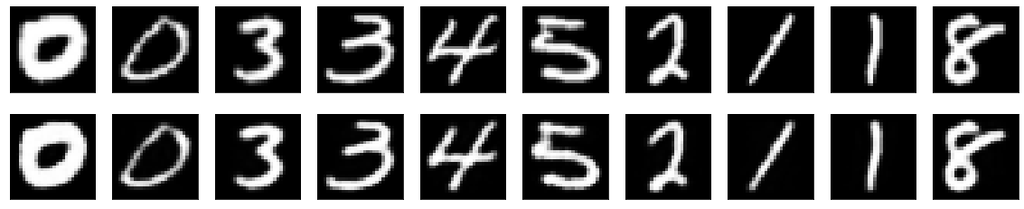

```python
n = 10  # how many digits we will display
plt.figure(figsize=(20, 4))
for i in range(n):
    # display original
    ax = plt.subplot(2, n, i + 1)
    plt.imshow(x_test[i].reshape(28, 28))
    plt.gray()
    ax.get_xaxis().set_visible(False)
    ax.get_yaxis().set_visible(False)

    # display reconstruction
    ax = plt.subplot(2, n, i + 1 + n)
    plt.imshow(decoded_imgs[i].reshape(28, 28))
    plt.gray()
    ax.get_xaxis().set_visible(False)
    ax.get_yaxis().set_visible(False)
plt.show()
```